# Alejandre_Valeria_T3_P4

Alejandre Sanjuán Carla Valeria

23/3/2022

## Red de señalización

1. Elabora una representación verbal de la red

Es una red que explica la transducción de señales de una planta y el activador o señal inicio de esta red es el ácido abscísico, y como resultado de esto obtendremos el cierre de los estomas en las hojas.

2. Elabora una tabla de posibles reglas de la red

Tenemos que cargar BoolNet para comenzar a utilizar loadNetwork y cargar la red base las tablas de verdad.

targets, factors

CIS, cGMP & cADPR & InsP3 cGMP, GC cADPR, ADPRc InsP3,PLC GC, NO ADPRc, NO PLC,CA2 NO, NOS NOS,CA2 CA2, CaIM & CIS & !CA2ATP CaIM,!Depolar CA2ATP, CA2 KEV, CA2 HATP, !CA2 AnionEM, CA2 Clousure, AnionEM & KOUT & KAP KOUT, Depolar KAP, Depolar Depolar, KEV & ! HATP & ! KOUT & AnionEM & CA2ATP

Graficamos la red para verificar que si interprete bien las reglas con las que se describe

```r
library(BoolNet)
red_4 <- loadNetwork("GNRnet.txt")
red_4
```

```
## Boolean network with 19 genes
##
## Involved genes:
## CIS cGMP cADPR InsP3 GC ADPRc PLC NO NOS CA2 CaIM CA2ATP KEV HATP AnionEM Clousure KOUT KAP Depolar
##
## Transition functions:
## CIS = cGMP & cADPR & InsP3
## cGMP = GC
## cADPR = ADPRc
## InsP3 = PLC
## GC = NO
## ADPRc = NO
## PLC = CA2
## NO = NOS
## NOS = CA2
## CA2 = CaIM & CIS & !CA2ATP
## CaIM = !Depolar
## CA2ATP = CA2
## KEV = CA2
## HATP = !CA2
## AnionEM = CA2
## Clousure = AnionEM & KOUT & KAP
## KOUT = Depolar
## KAP = Depolar
## Depolar = KEV & ! HATP & ! KOUT & AnionEM & CA2ATP
```

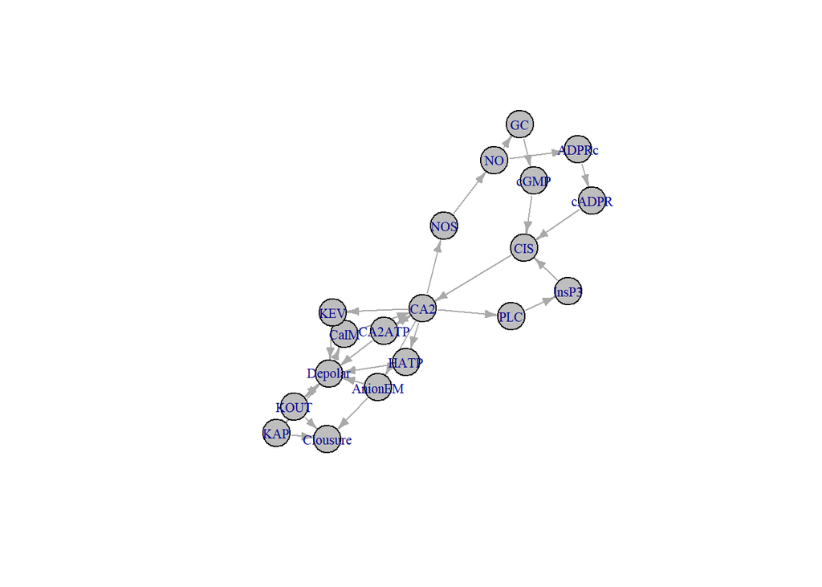

```r
plotNetworkWiring(red_4)
```

c)Encuentra y discute biologicamente el significado de los atractores

```r
atrac_4 <- getAttractors(red_4)

atrac_4
```

```
## Attractor 1 is a simple attractor consisting of 1 state(s) and has a basin of 524288 state(s):
##
##  |--<------------------|
##  V                     |
##  0000000000100100000   |
##  V                     |
##  |-->------------------|
##
##
## Genes are encoded in the following order: CIS cGMP cADPR InsP3 GC ADPRc PLC NO NOS CA2 CaIM CA2ATP KEV HATP AnionEM Clousure KOUT KAP Depolar
```

Graficamos los atractores

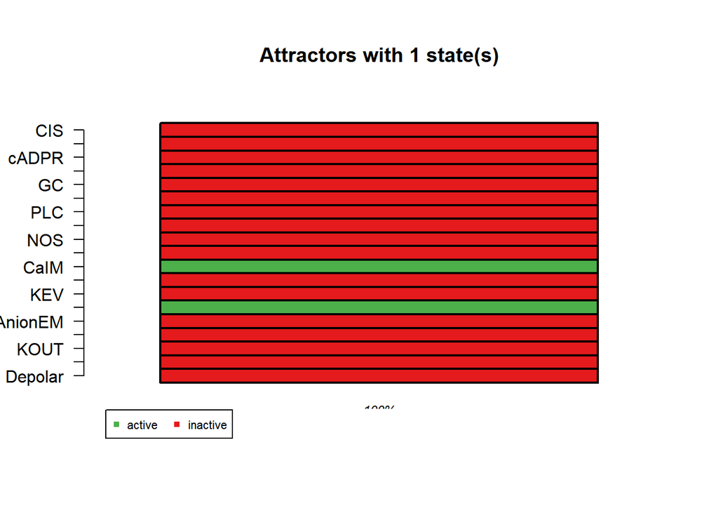

```
## $`1`
##          Attr1.1
## CIS            0
## cGMP           0
## cADPR          0
## InsP3          0
## GC             0
## ADPRc          0
## PLC            0
## NO             0
## NOS            0
## CA2            0
## CaIM           1
## CA2ATP         0
## KEV            0
## HATP           1
## AnionEM        0
## Clousure       0
## KOUT           0
## KAP            0
## Depolar        0
```

```r
plotAttractors(atrac_4)
```

Cuando todos estan apagados estos dos tenderan a estar activos para comenzar la activacion y la inihibicion de los mismos no puede estar activada porque afectaria la mitad de la regulación.